# TUGAS 1 TUTORIAL ONLINE

## DASAR PEMROGRAMAN R

- NAMA : RIZIQ LILI ULIL ALBAB
- NIM : 058487469

## NOTE: Tugas ini saya buat dengan menggunakan Jupyter Notebook

## NOMOR 1

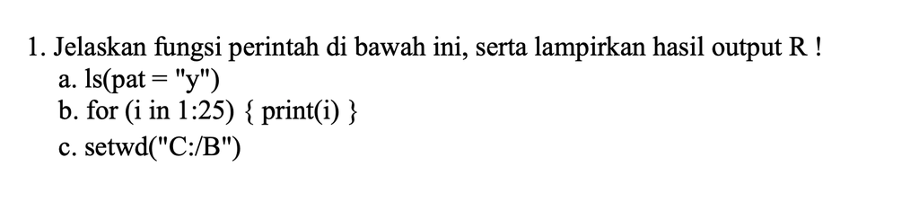

```r
## PEMBUATAN VARIABLE UNTUK STUDI KASUS
x <- 10
y <- 20
myData <- c(1,2,3)
z <- 5
```

a. Syntax ls(pat = "y") digunakan untuk menampilkan objek-objek yang namanya mengandung huruf "y". Dalam konteks ini, objek-objek tersebut adalah variabel atau fungsi yang telah didefinisikan dalam lingkungan kerja R yang namanya mengandung huruf "y".

CONTOH:

```r
ls(pat = "y")
```

1. 'myData'

2. 'y'

b. for (i in 1:25) { print(i) } adalah sebuah loop for yang akan mencetak angka dari 1 hingga 25. Loop ini akan berjalan sebanyak 25 kali, dan pada setiap iterasi, nilai i akan bertambah satu mulai dari 1 hingga mencapai 25. Setiap nilai i akan dicetak menggunakan fungsi print().

CONTOH:

```r
for (i in 1:25) { print(i) }
```

```
[1] 1
[1] 2
[1] 3
[1] 4
[1] 5
[1] 6
[1] 7
[1] 8
[1] 9
[1] 10
[1] 11
[1] 12
[1] 13
[1] 14
[1] 15
[1] 16
[1] 17
[1] 18
[1] 19
[1] 20
[1] 21
[1] 22
[1] 23
[1] 24
[1] 25
```

c. setwd("C:/B") digunakan untuk mengubah direktori kerja saat ini ke direktori "C:/B". Ini berarti bahwa setelah menjalankan perintah ini, semua operasi file yang dilakukan akan dilakukan di dalam direktori "C:/B".

```r
setwd("C:/B")
```

```
Error in setwd("C:/B"): cannot change working directory
Traceback:

1. .handleSimpleError(function (cnd)
 . {
 .     watcher$capture_plot_and_output()
 .     cnd <- sanitize_call(cnd)
 .     watcher$push(cnd)
 .     switch(on_error, continue = invokeRestart("eval_continue"),
 .         stop = invokeRestart("eval_stop"), error = NULL)
 . }, "cannot change working directory", base::quote(setwd("C:/B")))
```

Kenapa error? Karena direktori "C:/B" tidak ada di sistem file komputer ketika menjalankan perintah setwd() ini. Jika direktori tersebut tidak ada, R akan menghasilkan error karena tidak dapat menemukan lokasi yang ditentukan. Pastikan bahwa direktori "C:/B" benar-benar ada sebelum menjalankan perintah setwd() untuk menghindari error tersebut.

## NOMOR 2

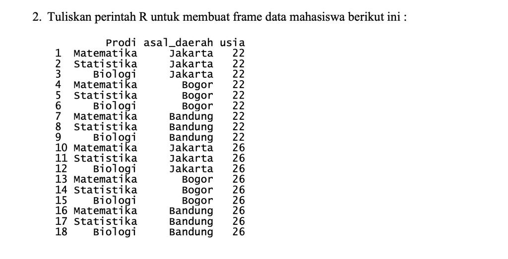

```r
prodi <- rep(c("Matematika", "Statistika", "Biologi"), 6)
asal_daerah <- rep(c("Jakarta", "Bogor", "Bandung"), each = 3, times = 2)
usia <- c(rep(22, 9), rep(26, 9))

mahasiswa <- data.frame(prodi, asal_daerah, usia)

print(mahasiswa)
```

```
        prodi asal_daerah usia
1  Matematika     Jakarta   22
2  Statistika     Jakarta   22
3     Biologi     Jakarta   22
4  Matematika       Bogor   22
5  Statistika       Bogor   22
6     Biologi       Bogor   22
7  Matematika     Bandung   22
8  Statistika     Bandung   22
9     Biologi     Bandung   22
10 Matematika     Jakarta   26
11 Statistika     Jakarta   26
12    Biologi     Jakarta   26
13 Matematika       Bogor   26
14 Statistika       Bogor   26
15    Biologi       Bogor   26
16 Matematika     Bandung   26
17 Statistika     Bandung   26
18    Biologi     Bandung   26
```

## NOMOR 3

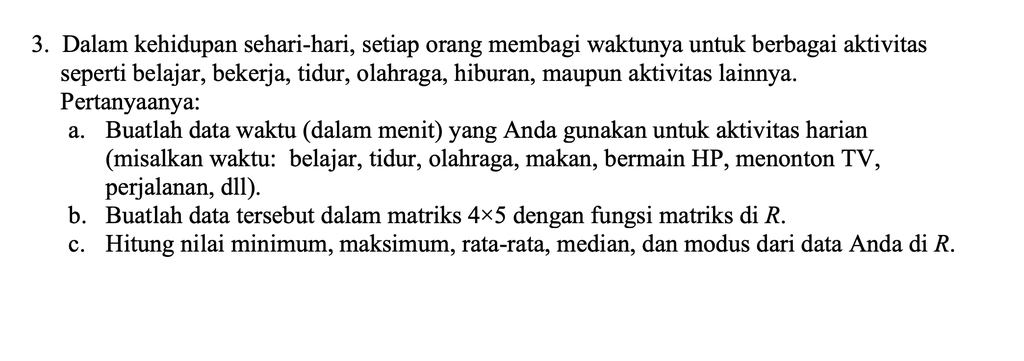

### A

```r
c(120, 420, 60, 90, 180, 45, 30, 60, 240, 50, 80, 70, 100, 200, 55, 65, 75, 85, 95, 110)
```

1. 120

2. 420

3. 60

4. 90

5. 180

6. 45

7. 30

8. 60

9. 240

10. 50

11. 80

12. 70

13. 100

14. 200

15. 55

16. 65

17. 75

18. 85

19. 95

20. 110

### B

```r
data <- c(120,420,60,90,180,
          45,30,60,240,50,
          80,70,100,200,55,
          65,75,85,95,110)

m <- matrix(data, nrow=4, ncol=5, byrow=TRUE)
m
```

A matrix: 4 × 5 of type dbl

| 120 | 420 | 60 | 90 | 180 |
| --- | --- | --- | --- | --- |
| 45 | 30 | 60 | 240 | 50 |
| 80 | 70 | 100 | 200 | 55 |
| 65 | 75 | 85 | 95 | 110 |

```r
min_val <- min(m)
max_val <- max(m)
mean_val <- mean(m)
median_val <- median(m)

# modus (manual)
modus <- function(x){
  ux <- unique(x)
  ux[which.max(tabulate(match(x, ux)))]
}
mode_val <- modus(m)

print("Maximum Value:")
max_val
print("Mean Value:")
mean_val
print("Median Value:")
median_val
print("Mode Value:")
mode_val
```

[output not shown]

```
[1] "Maximum Value:"
```

420

```
[1] "Mean Value:"
```

111.5

```
[1] "Median Value:"
```

82.5

```
[1] "Mode Value:"
```

60